# Reproductive Health Survey

This is a dataset from the Mongolian Statistical Microdata. The Reproductive Health Survey was conducted by NSO for 3 times, the previous two times were in 1998 and 2003. As it is stated on the website "The importance of this survey is to provide data for a wide range of activities, including monitoring the indicators of the Millenium Development Goals, evaluating policies at the international and national levels, assessing required measures related to programme implementation in the future, and conducting additional in-depth research and analysis". The survey's purpose was to gather data on the reproductive health indicators such as fertility, infant and child mortality, factors affecting mortality, child health, family planning and STI/HIV/AIDS, women's knowledge on reproductive diseases, etc.

I wanted to know the situation of women in Mongolia, especially those who have children. There were three datasets in this survey, but I decided to use only one dataset `women`. I don't think I am able to fully use all the data provided in this survey, but hopefully in the future I will be able to do that.

I chose the Reproductive Health Survey 2008 from the [Microdata of National Statistics Office of Mongolia](http://web.nso.mn/nada/index.php/catalog/74/study-description)

## 1. Importing Libraries

```python
import pandas as pd
import numpy as np
import matplotlib.pyplot as plt
```

## 2. Importing the dataset

```python
women = pd.read_spss('Women.sav')
```

```python
women
```

|  | CLUSTER | HHN | RESPNO | H36 | HUSQUEST | HUSLN | WMONTH | WDAY | region | WRESULT | ... | H418B | H419 | H420 | H421 | H422 | H423A | H423B | H424 | H425H | H425M |
| --- | --- | --- | --- | --- | --- | --- | --- | --- | --- | --- | --- | --- | --- | --- | --- | --- | --- | --- | --- | --- | --- |
| 0 | 1.0 | 1.0 | 2.0 | Less than 28264 | Yes | 1.0 | 9.0 | 22.0 | Central | Completed | ... | NaN | NaN | NaN | NaN | I did not have time | Months ago | 1.0 | NaN | 16.0 | 15.0 |
| 1 | 1.0 | 2.0 | 2.0 | 28265-70660 | Yes | 1.0 | 9.0 | 24.0 | Central | Completed | ... | NaN | NaN | NaN | NaN | I did not have time | Days ago | 7.0 | 3.0 | 10.0 | 50.0 |
| 2 | 1.0 | 3.0 | 2.0 | 28265-70660 | Yes | 1.0 | 9.0 | 23.0 | Central | Completed | ... | NaN | NaN | NaN | NaN | I don't think I am at risk of having HIV | Days ago | 1.0 | 3.0 | 16.0 | 37.0 |
| 3 | 1.0 | 4.0 | 2.0 | 28265-70660 | Yes | 1.0 | 9.0 | 23.0 | Central | Completed | ... | NaN | NaN | NaN | NaN | I don't think I am at risk of having HIV | Weeks ago | 1.0 | 3.0 | 16.0 | 10.0 |
| 4 | 1.0 | 5.0 | 2.0 | 28265-70660 | Yes | 1.0 | 9.0 | 22.0 | Central | Completed | ... | NaN | NaN | NaN | NaN | Did not know that HIV testing is available | Days ago | 2.0 | 3.0 | 15.0 | 18.0 |
| ... | ... | ... | ... | ... | ... | ... | ... | ... | ... | ... | ... | ... | ... | ... | ... | ... | ... | ... | ... | ... | ... |
| 9520 | 280.0 | 26.0 | 3.0 | More than 123786 | No | NaN | 11.0 | 19.0 | South | Completed | ... | NaN | NaN | NaN | NaN | NaN | NaN | NaN | NaN | NaN | NaN |
| 9521 | 280.0 | 27.0 | 2.0 | Less than 28264 | Yes | 1.0 | 11.0 | 19.0 | South | Completed | ... | NaN | NaN | NaN | NaN | I don't think I am at risk of having HIV | Months ago | 2.0 | NaN | 21.0 | 50.0 |
| 9522 | 280.0 | 28.0 | 2.0 | Less than 28264 | No | NaN | 11.0 | 19.0 | South | Completed | ... | NaN | NaN | NaN | NaN | NaN | NaN | NaN | NaN | NaN | NaN |
| 9523 | 280.0 | 29.0 | 2.0 | 28265-70660 | No | NaN | 11.0 | 19.0 | South | Completed | ... | NaN | NaN | NaN | NaN | NaN | NaN | NaN | NaN | NaN | NaN |
| 9524 | 280.0 | 30.0 | 2.0 | 28265-70660 | No | NaN | 11.0 | 19.0 | South | Completed | ... | NaN | NaN | NaN | NaN | NaN | NaN | NaN | NaN | NaN | NaN |

9525 rows × 627 columns

## 3. Data Cleaning

```python
columns_women = ['Q102', 'Q106W', 'Q112', 'Q116', 'Q200', 'Q209', 'Q207', 'Q501', 'Q502', 'Q506']
```

```python
women = women[columns_women]
```

```python
women.rename(columns= ({'Q102': 'Current age', 'Q106W': 'Education', 'Q112': 'Marital status',
                        'Q116': 'Age at marriage', 'Q200': 'Ever given birth', 'Q209': 'Age at first birth',
                        'Q207': 'Total number of children', 'Q501': 'Want more children',
                        'Q502': 'Number of additional children wanted', 'Q506': 'Ideal number of children'}), inplace=True)
```

```python
women
```

|  | Current age | Education | Marital status | Age at marriage | Ever given birth | Age at first birth | Total number of children | Want more children | Number of additional children wanted | Ideal number of children |
| --- | --- | --- | --- | --- | --- | --- | --- | --- | --- | --- |
| 0 | 27.0 | Primary or Less | Married | 18.0 | Yes | 19.0 | 2.0 | Undecided | NaN | 3.0 |
| 1 | 44.0 | Incomplete Secondary | Married | 18.0 | Yes | 20.0 | 5.0 | No | NaN | 4.0 |
| 2 | 30.0 | Incomplete Secondary | Married | 22.0 | Yes | 22.0 | 2.0 | Yes | 1.0 | 3.0 |
| 3 | 24.0 | Complete Secondary | Married | 18.0 | Yes | 19.0 | 2.0 | Undecided | NaN | 3.0 |
| 4 | 23.0 | Primary or Less | Married | 23.0 | Yes | 20.0 | 1.0 | Yes | 1.0 | 2.0 |
| ... | ... | ... | ... | ... | ... | ... | ... | ... | ... | ... |
| 9520 | 23.0 | More than Secondary | Single | NaN | No | NaN | No child | Yes | 3.0 | 3.0 |
| 9521 | 35.0 | Primary or Less | Married | 23.0 | Yes | 25.0 | 3.0 | No | NaN | 5.0 |
| 9522 | 30.0 | Complete Secondary | Married | 22.0 | Yes | 22.0 | 2.0 | Undecided | NaN | 3.0 |
| 9523 | 34.0 | Complete Secondary | Married | 20.0 | Yes | 21.0 | 3.0 | Yes | 1.0 | 4.0 |
| 9524 | 32.0 | Complete Secondary | Married | 18.0 | Yes | 20.0 | 3.0 | No | NaN | 3.0 |

9525 rows × 10 columns

There were too many columns, so I chose only those I needed/was interested in. The column names made no sense to me, that's why I had to rename all the columns I needed.

```python
women.shape
```

```
(9525, 10)
```

```python
women.isnull().any()
```

```
Current age                             True
Education                               True
Marital status                          True
Age at marriage                         True
Ever given birth                        True
Age at first birth                      True
Total number of children                True
Want more children                      True
Number of additional children wanted    True
Ideal number of children                True
dtype: bool
```

```python
women.isnull().sum()
```

```
Current age                              122
Education                                255
Marital status                           122
Age at marriage                         2132
Ever given birth                         123
Age at first birth                      2044
Total number of children                 122
Want more children                       325
Number of additional children wanted    5545
Ideal number of children                 123
dtype: int64
```

```python
women.isnull().sum() / women.shape[0]
```

```
Current age                             0.012808
Education                               0.026772
Marital status                          0.012808
Age at marriage                         0.223832
Ever given birth                        0.012913
Age at first birth                      0.214593
Total number of children                0.012808
Want more children                      0.034121
Number of additional children wanted    0.582152
Ideal number of children                0.012913
dtype: float64
```

```python
women.isnull().sum().sum()
```

```
10913
```

I am going to create a mask for the whole dataframe. It will show boolean values whether each cell is NaN or not. This method was shown on the "Crime Cleaning" class.

```python
mask = women.isnull()
```

This is going to look to see if there is at least 1 True value in each row, then we will save that to a row mask.

```python
row_mask = mask.any(axis=1)
row_mask
```

```
0        True
1        True
2       False
3        True
4       False
        ...
9520     True
9521     True
9522     True
9523    False
9524     True
Length: 9525, dtype: bool
```

```python
women = women[~row_mask]
```

```python
women.shape
```

```
(2182, 10)
```

```python
women.isnull().sum()
```

```
Current age                             0
Education                               0
Marital status                          0
Age at marriage                         0
Ever given birth                        0
Age at first birth                      0
Total number of children                0
Want more children                      0
Number of additional children wanted    0
Ideal number of children                0
dtype: int64
```

```python
women
```

|  | Current age | Education | Marital status | Age at marriage | Ever given birth | Age at first birth | Total number of children | Want more children | Number of additional children wanted | Ideal number of children |
| --- | --- | --- | --- | --- | --- | --- | --- | --- | --- | --- |
| 2 | 30.0 | Incomplete Secondary | Married | 22.0 | Yes | 22.0 | 2.0 | Yes | 1.0 | 3.0 |
| 4 | 23.0 | Primary or Less | Married | 23.0 | Yes | 20.0 | 1.0 | Yes | 1.0 | 2.0 |
| 19 | 30.0 | Primary or Less | Married | 19.0 | Yes | 21.0 | 2.0 | Yes | 2.0 | 6.0 |
| 20 | 20.0 | Complete Secondary | Married | 20.0 | Yes | 19.0 | 1.0 | Yes | 1.0 | 2.0 |
| 26 | 39.0 | Complete Secondary | Married | 22.0 | Yes | 24.0 | 1.0 | Yes | 1.0 | 2.0 |
| ... | ... | ... | ... | ... | ... | ... | ... | ... | ... | ... |
| 9512 | 20.0 | Complete Secondary | Married | 18.0 | Yes | 19.0 | 1.0 | Yes | 1.0 | 3.0 |
| 9514 | 23.0 | Complete Secondary | Married | 21.0 | Yes | 20.0 | 1.0 | Yes | 2.0 | 3.0 |
| 9515 | 35.0 | Complete Secondary | Married | 19.0 | Yes | 19.0 | 2.0 | Yes | 2.0 | 4.0 |
| 9518 | 30.0 | Complete Secondary | Married | 20.0 | Yes | 21.0 | 1.0 | Yes | 1.0 | 2.0 |
| 9523 | 34.0 | Complete Secondary | Married | 20.0 | Yes | 21.0 | 3.0 | Yes | 1.0 | 4.0 |

2182 rows × 10 columns

```python
women['Ever given birth'].unique()
```

```
['Yes']
Categories (2, object): ['No', 'Yes']
```

When I removed all the NaN's from column `Age at first birth`, all the `No` values in `Ever given birth` column got removed. I wanted to get data about only those women who have given birth before.

```python
women = women.drop(['Ever given birth'], axis = 1)
```

```python
women
```

|  | Current age | Education | Marital status | Age at marriage | Age at first birth | Total number of children | Want more children | Number of additional children wanted | Ideal number of children |
| --- | --- | --- | --- | --- | --- | --- | --- | --- | --- |
| 2 | 30.0 | Incomplete Secondary | Married | 22.0 | 22.0 | 2.0 | Yes | 1.0 | 3.0 |
| 4 | 23.0 | Primary or Less | Married | 23.0 | 20.0 | 1.0 | Yes | 1.0 | 2.0 |
| 19 | 30.0 | Primary or Less | Married | 19.0 | 21.0 | 2.0 | Yes | 2.0 | 6.0 |
| 20 | 20.0 | Complete Secondary | Married | 20.0 | 19.0 | 1.0 | Yes | 1.0 | 2.0 |
| 26 | 39.0 | Complete Secondary | Married | 22.0 | 24.0 | 1.0 | Yes | 1.0 | 2.0 |
| ... | ... | ... | ... | ... | ... | ... | ... | ... | ... |
| 9512 | 20.0 | Complete Secondary | Married | 18.0 | 19.0 | 1.0 | Yes | 1.0 | 3.0 |
| 9514 | 23.0 | Complete Secondary | Married | 21.0 | 20.0 | 1.0 | Yes | 2.0 | 3.0 |
| 9515 | 35.0 | Complete Secondary | Married | 19.0 | 19.0 | 2.0 | Yes | 2.0 | 4.0 |
| 9518 | 30.0 | Complete Secondary | Married | 20.0 | 21.0 | 1.0 | Yes | 1.0 | 2.0 |
| 9523 | 34.0 | Complete Secondary | Married | 20.0 | 21.0 | 3.0 | Yes | 1.0 | 4.0 |

2182 rows × 9 columns

Now we don't need the `Ever given birth` column, so I removed it.

### Making sure that all the datatypes are correct

```python
women.dtypes
```

```
Current age                              float64
Education                               category
Marital status                          category
Age at marriage                          float64
Age at first birth                       float64
Total number of children                category
Want more children                      category
Number of additional children wanted     float64
Ideal number of children                 float64
dtype: object
```

```python
cols = ['Current age', 'Age at marriage', 'Age at first birth', 'Number of additional children wanted', 'Ideal number of children']
women[cols] = women[cols].astype('int64')
```

I changed all the float64 collumns into int64. One numeric column's (`Total number of children`) data type is `category`. In order to change it into int64, I need the change the value 'No child' into `0`

```python
women.replace({'Total number of children':{'No child':0}}, inplace = True)
```

```python
women['Total number of children'] = women['Total number of children'].astype(np.int64)
```

```python
women.dtypes
```

```
Current age                                int64
Education                               category
Marital status                          category
Age at marriage                            int64
Age at first birth                         int64
Total number of children                   int64
Want more children                      category
Number of additional children wanted       int64
Ideal number of children                   int64
dtype: object
```

## 4. EDA with Analysis

### Exploring numeric features:

1. Age at marriage and Age at first birth
2. Total number of children and Ideal number of children
3. Age at marriage and the total number of children

```python
women.describe()
```

|  | Current age | Age at marriage | Age at first birth | Total number of children | Number of additional children wanted | Ideal number of children |
| --- | --- | --- | --- | --- | --- | --- |
| count | 2182.000000 | 2182.000000 | 2182.000000 | 2182.000000 | 2182.000000 | 2182.000000 |
| mean | 28.546746 | 22.069661 | 22.365720 | 1.626031 | 1.477085 | 3.433547 |
| std | 5.217715 | 3.509299 | 3.299518 | 0.810534 | 0.684657 | 0.930374 |
| min | 16.000000 | 15.000000 | 15.000000 | 1.000000 | 1.000000 | 0.000000 |
| 25% | 25.000000 | 20.000000 | 20.000000 | 1.000000 | 1.000000 | 3.000000 |
| 50% | 28.000000 | 22.000000 | 22.000000 | 1.000000 | 1.000000 | 3.000000 |
| 75% | 32.000000 | 24.000000 | 24.000000 | 2.000000 | 2.000000 | 4.000000 |
| max | 46.000000 | 39.000000 | 37.000000 | 10.000000 | 6.000000 | 10.000000 |

#### 1. Age at marriage and Age at first birth

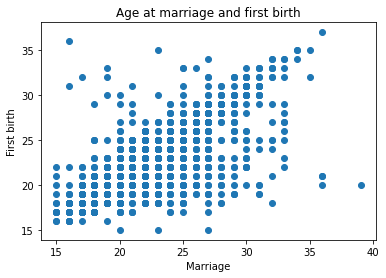

```python
plt.scatter(women['Age at marriage'], women['Age at first birth'])
plt.title('Age at marriage and first birth')
plt.xlabel('Marriage')
plt.ylabel('First birth')
```

#### 2. Total number of children and Ideal number of children

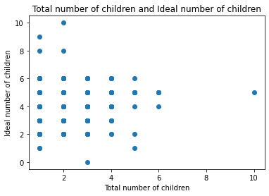

```python
plt.scatter(women['Total number of children'], women['Ideal number of children'])
plt.title('Total number of children and Ideal number of children')
plt.xlabel('Total number of children')
plt.ylabel('Ideal number of children')
```

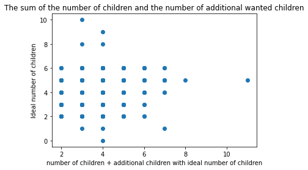

```python
plt.scatter(women['Total number of children'] + women['Number of additional children wanted'], women['Ideal number of children'])
plt.title('The sum of the number of children and the number of additional wanted children')
plt.xlabel('number of children + additional children with ideal number of children')
plt.ylabel('Ideal number of children')
```

#### 3. Age at marriage and the total number of children

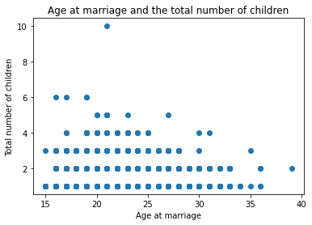

```python
plt.scatter(women['Age at marriage'], women['Total number of children'])
plt.title('Age at marriage and the total number of children')
plt.xlabel('Age at marriage')
plt.ylabel('Total number of children')
```

#### 4. Age at first birth and number of additional children wanted

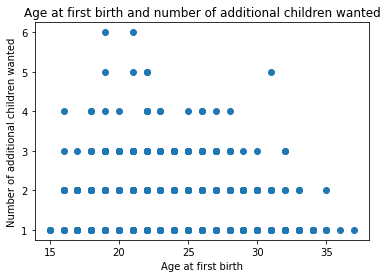

```python
plt.scatter(women['Age at first birth'], women['Number of additional children wanted'])
plt.title('Age at first birth and number of additional children wanted')
plt.xlabel('Age at first birth')
plt.ylabel('Number of additional children wanted')
```

I think it's not useful to explore the numerical features. A lot of the features overlap, it is hard to understand.

### Exploring categorical and numeric features:

1. Age at first birth by education level
2. Age at marriage by education level
3. Ideal number of children by education

#### 1. Age at first birth by education level

```python
edu_birth = women[['Education', 'Age at first birth']]
```

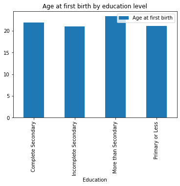

```python
edu_birth.groupby(['Education']).mean().plot(kind='bar', title='Age at first birth by education level')
```

#### Conclusion:

`Incomplete secondary` and `Primary or less` have a younger average age of first birth. Lower education, earlier the first birth

#### 2. Age at marriage by education level

```python
edu_marriage = women[['Education', 'Age at marriage']]
```

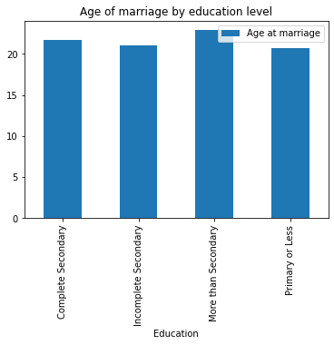

```python
edu_marriage.groupby(['Education']).mean().plot(kind='bar', title='Age of marriage by education level')
```

#### Conclusion:

Not much difference besides `Incomplete secondary` and `Primary or less` having a younger average age

#### 3. Ideal number of children by education

```python
edu_ideal = women[['Ideal number of children', 'Education']]
```

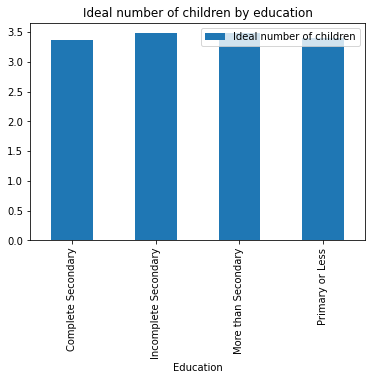

```python
edu_ideal.groupby(['Education']).mean().plot(kind='bar', title='Ideal number of children by education')
```

#### Conclusion:

There is not much difference in the ideal number of children by education

### Exploring categorical features:

1. Women who want more children by their marital status
2. Number of separated women by education level

#### 1. Women who want more children by their marital status

```python
status_more = women[['Marital status', 'Want more children']]
```

```python
status_yes = status_more[status_more['Want more children'] == 'Yes'].groupby(['Marital status']).size()
```

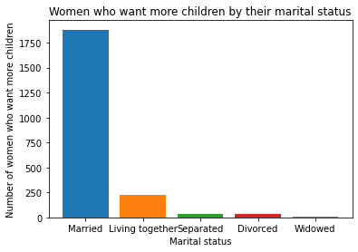

```python
plt.bar("Married", status_yes["Married"])
plt.bar("Living together", status_yes["Living together"])
plt.bar("Separated", status_yes["Separated"])
plt.bar("Divorced", status_yes["Divorced"])
plt.bar("Widowed", status_yes["Widowed"])
plt.title('Women who want more children by their marital status')
plt.xlabel('Marital status')
plt.ylabel('Number of women who want more children')
```

#### Conclusion:

Obviously married women want more children than the rest

#### 2. Number of separated women by education level

```python
status_edu = women[['Marital status', 'Education']]
```

```python
status_widow = status_edu[status_edu['Marital status'] == 'Separated'].groupby(['Education']).size()
```

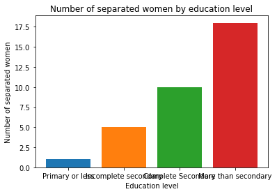

```python
plt.bar("Primary or less", status_widow["Primary or Less"])
plt.bar("Incomplete secondary", status_widow["Incomplete Secondary"])
plt.bar("Complete Secondary", status_widow["Complete Secondary"])
plt.bar("More than secondary", status_widow["More than Secondary"])
plt.title('Number of separated women by education level')
plt.xlabel('Education level')
plt.ylabel('Number of separated women')
```

#### Conclusion:

Most of the separated women have more than secondary education